# Bio File Formats in R

Bio File Formats in R David C. King 2025-03-02

## File formats in biology

Many file formats in biology are plain text, but conform to a certain structure.

- Sequences- DNA, RNA, protein
- Sequence reads - fastq
- Sequence Alignments- MAF, SAM/BAM
- Phylogenetic trees - Newick, Phylip
- Genomic Coordinates and Annotations - BED, GTF, GFF
- Microscopy images - tiff, raw
- Protein Structure - pdb
- Mass Spectrography
- Analysis output – tidy data, csv
- Compressed files - gzip, tar, zip

## DNA/RNA and Amino Acid Sequences

Purpose:

- Understand sequence content, properties.
- Domains/Structure/Function.
- Variation: SNPs, indels, transitions/transversions.
- Identity of a gene, relationship to other genes, other species (paralogs/orthologs).
- Next-gen sequencing- the presence and identity of the sequence is a measurement (a count of expressed transcripts, enriched fragments)
- Design primers for PCR

### FASTA Format

Comes from FAST sequence aligner. Fast**n**: nucleotide; Fast**p**: protein: Fast**a**: all.

Definition:

https://en.wikipedia.org/wiki/FASTA_format

https://www.ncbi.nlm.nih.gov/genbank/fastaformat/

1. Header line starts with “>” followed by the name of the sequence. More information can be provided but must be on the same line.
2. Sequence follows on one or more lines.
3. Multiple header/sequence pairs can be in the same file (sometimes this is called “multi-fasta”)

Examples:

```
>gi|1817694395|ref|NZ_JAAGMU010000151.1| Streptomyces sp. SID7958 contig-52000002, whole genome shotgun sequence
CCGGCTGGCGCGGCTGGCGCTGGCGGTGGGGCTGCGGCTGCTGGAGCTGGGGGTGGCGCTGGAGGCGCAC
GGCCAGAACCTGCTGGTGGTGCTGTCGCCGTCCGGGGAGCCGCGGCGGCTGGTCTACCGCGATCTGGCGG
ACATCCGGGTCTCCCCCGCGCGGCTGGCCCGGCACGGTATCCGGGTTCCGGACCTGCCGGCG

>gi|1643051563|gb|SZWM01000399.1| Citrobacter sp. TBCS-14 contig3128, whole genome shotgun sequence
GCACAGTGAGATCAGCATTCCGTTGGATCTACTGGTCAATCAAAACCTGACGCTGGGTACTGAATGGAAC
CAGCAGCGCATGAAGGACATGCTGTCTAACTCGCAGACCTTTATGGGCGGTAATATTCCAGGCTACAGCA
GCACCGATCGCAGCCCATATTCGAAAGCCGAGATCTTCTCTTTGTTTGCCGAAAACAACATG
```

These sequences have a complex header with multiple, |-delimited fields.

What’s missing? Sequence annotations and features.

- Example: Say there is a stem-loop at position 150-200. Have to record it separately.
- Exception: masking with uppercase/lowercase, or another symbol (i.e. N, X)

#### Masking

Sequence aligners are often tripped up by short repeat fragments and low complexity regions. RepeatMasker is a common tool for finding repeats and *masking* them.

One convention is to use the character N for a hard-masked DNA sequence, or use lowercase letters for softmasking. *This doesn’t work if N is being used for an ambiguity (the exact base at that position is uncertain).*

##### Hard Masking

(David made this example up)

In the Streptomyces example above, replace nucleotide letter with ‘N’ if sequence is in a repeat (found by RepeatMasker)

```
CCGGCTGGCGCGGCTGGCGCTGGCGGTGGGGCTGCGGCTGCTGGAGCTGGGGGNNNNNNNNNNNNNNNNN
NNNNNNNNNNNNNNNNNNNNNNNNNNNNNNNNNNNNNNNNNNNNNNNNCTGGTCTACCGCGATCTGGCGG
ACATCCGGGTCTCCCCCGCGCGGCTGGCCCGGCACGGTATCCGGGTTCCGGACCTGCCGGCG
```

Software that deals with sequence analysis will be forced to ignore the N’s., but maintain the spacing.

##### Soft Masking

Sometimes you want to retain the sequence, but convey that it is masked. This is usually done with the masked bases being converted to lowercase.

```
CCGGCTGGCGCGGCTGGCGCTGGCGGTGGGGCTGCGGCTGCTGGAGCTGGGGGtggcgctggaggcgcac
ggccagaacctgctggtggtgctgtcgccgtccggggagccgcggcggCTGGTCTACCGCGATCTGGCGG
ACATCCGGGTCTCCCCCGCGCGGCTGGCCCGGCACGGTATCCGGGTTCCGGACCTGCCGGCG
```

Software might not take case into account, it depends on the application, and behavior can be configured.

### In R

```r
# Read from a fasta file
seqs = readDNAStringSet("seqs_for_markdown.fasta")
seqs
```

```
## DNAStringSet object of length 2:
##     width seq                                               names
## [1]   202 CCGGCTGGCGCGGCTGGCGCTGG...TCCGGGTTCCGGACCTGCCGGCG gi|1817694395|ref...
## [2]   202 GCACAGTGAGATCAGCATTCCGT...CTTTGTTTGCCGAAAACAACATG gi|1643051563|gb|...
```

```r
# Save the names because they are long, and use shorter ones
long_names = names(seqs)
names(seqs) = c("Streptomyces","Citrobacter")
seqs
```

```
## DNAStringSet object of length 2:
##     width seq                                               names
## [1]   202 CCGGCTGGCGCGGCTGGCGCTGG...TCCGGGTTCCGGACCTGCCGGCG Streptomyces
## [2]   202 GCACAGTGAGATCAGCATTCCGT...CTTTGTTTGCCGAAAACAACATG Citrobacter
```

```r
# Some functions

## Dinucleotide frequencies
oligonucleotideFrequency(seqs[1], 2)
```

```
##      AA AC AG AT CA CC CG CT GA GC GG GT TA TC TG TT
## [1,]  1  6  4  3  4 18 28 17  7 33 39 10  2  9 19  1
```

```r
oligonucleotideFrequency(seqs[2], 1, as.prob=T)
```

```
##              A         C         G         T
## [1,] 0.2772277 0.2574257 0.2376238 0.2277228
```

```r
# look at hexamers for the most common ones
hexamer_frequencies = oligonucleotideFrequency(seqs[1], 6) # matrix of one row, 4096 columns
hexamer_frequencies[1,1:10] # can't use head on a wide object like this
```

```
## AAAAAA AAAAAC AAAAAG AAAAAT AAAACA AAAACC AAAACG AAAACT AAAAGA AAAAGC
##      0      0      0      0      0      0      0      0      0      0
```

```r
descending_order = order(hexamer_frequencies, decreasing = TRUE) # returns the INDEX of the the largest hex frequency, followed by the next largest, etc.
descending_order[1:10] # top 10 hexamer indices
```

```
##  [1] 1695 1959 2472 2538 2683 1642 3435 3738  378  859
```

```r
hexamer_frequencies[,descending_order[1:10]] # top ten hexamers (in a matrix)
```

```
## CGGCTG CTGGCG GCGGCT GCTGGC GGCTGG CGCGGC TCCGGG TGGCGC ACCTGC ATCCGG
##      5      4      4      4      4      3      3      3      2      2
```

```r
top10 = names(hexamer_frequencies[,descending_order[1:10]]) # get the hexamers from the names


# turn the top10 into a sequence object
dict0 = DNAStringSet(top10)
pdict0 = PDict(dict0) # PDict for Pattern DICTionary

# find the occurences of the top 10 hexamers in the sequence
matches = matchPDict(pdict0, seqs[[1]])
for (i in 1:10) {print(top10[i]); print(replaceAt(seqs[[1]], matches[[i]], value = 'NNNNNN'))}
```

```
## [1] "CGGCTG"
## 202-letter DNAString object
## seq: CNNNNNNGCGNNNNNNGCGCTGGCGGTGGGGCTGNN...GCCCGGCACGGTATCCGGGTTCCGGACCTGCCGGCG
## [1] "CTGGCG"
## 202-letter DNAString object
## seq: CCGGNNNNNNCGGNNNNNNNNNNNNGTGGGGCTGCG...GCCCGGCACGGTATCCGGGTTCCGGACCTGCCGGCG
## [1] "GCGGCT"
## 202-letter DNAString object
## seq: CCGGCTGGCNNNNNNGGCGCTGGCGGTGGGGCTNNN...GCCCGGCACGGTATCCGGGTTCCGGACCTGCCGGCG
## [1] "GCTGGC"
## 202-letter DNAString object
## seq: CCGNNNNNNGCGNNNNNNNNNNNNGGTGGGGCTGCG...NNCCGGCACGGTATCCGGGTTCCGGACCTGCCGGCG
## [1] "GGCTGG"
## 202-letter DNAString object
## seq: CCNNNNNNCGCNNNNNNCGCTGGCGGTGGGGCTGCG...NCCCGGCACGGTATCCGGGTTCCGGACCTGCCGGCG
## [1] "CGCGGC"
## 202-letter DNAString object
## seq: CCGGCTGGNNNNNNTGGCGCTGGCGGTGGGGCTGCG...GCCCGGCACGGTATCCGGGTTCCGGACCTGCCGGCG
## [1] "TCCGGG"
## 202-letter DNAString object
## seq: CCGGCTGGCGCGGCTGGCGCTGGCGGTGGGGCTGCG...GCCCGGCACGGTANNNNNNTTCCGGACCTGCCGGCG
## [1] "TGGCGC"
## 202-letter DNAString object
## seq: CCGGCNNNNNNGGCNNNNNNTGGCGGTGGGGCTGCG...GCCCGGCACGGTATCCGGGTTCCGGACCTGCCGGCG
## [1] "ACCTGC"
## 202-letter DNAString object
## seq: CCGGCTGGCGCGGCTGGCGCTGGCGGTGGGGCTGCG...GCCCGGCACGGTATCCGGGTTCCGGNNNNNNCGGCG
## [1] "ATCCGG"
## 202-letter DNAString object
## seq: CCGGCTGGCGCGGCTGGCGCTGGCGGTGGGGCTGCG...GCCCGGCACGGTNNNNNNGTTCCGGACCTGCCGGCG
```

```r
expectedDinucleotideFrequency <- function(x)
{
    # Individual base frequencies.
    bf <- alphabetFrequency(x, baseOnly=TRUE)[DNA_BASES]
    (as.matrix(bf) %*% t(bf) - diag(bf)) / length(x)
}

## On Celegans chrI:
library(BSgenome.Celegans.UCSC.ce11)
chrI <- Celegans$chrI
obs_df <- dinucleotideFrequency(chrI, as.matrix=TRUE)
obs_df  # CG has the lowest frequency
```

```
##         A      C      G       T
## A 2049736 704043 758861 1323299
## C  909649 521372 503518  761350
## G  953429 515117 518679  704930
## T  923125 955358 911096 2058871
```

```r
exp_df <- expectedDinucleotideFrequency(chrI)
## A sanity check:
stopifnot(as.integer(sum(exp_df)) == sum(obs_df))

## Ratio of observed frequency to expected frequency:
obs_df / exp_df  # TA has the lowest ratio, not CG!
```

```
##           A         C         G         T
## A 1.3210516 0.8139535 0.8785465 0.8506632
## C 1.0516573 1.0812520 1.0456736 0.8779356
## G 1.1038012 1.0697617 1.0786538 0.8140037
## T 0.5934173 1.1016520 1.0520698 1.3200998
```

## Annotation Databases

Gene annotations, sequences, other data that can be mapped to genes from a variety of sources/experiments.

NCBI - National Center for Biotechnology Information

UCSC Genome Browser - University of California Santa Cruz

[Ensembl](https://useast.ensembl.org/index.html) - European Bioinformatics Institute

### Ensembl Genome Browser

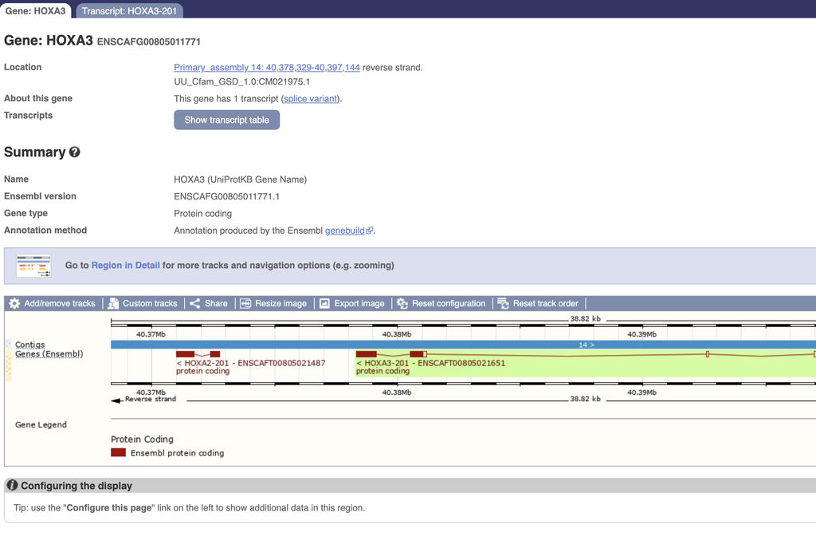

#### Tracks and Configuration

- Tracks displayed in screenshot
  - Contigs - sequence assembly
  - Genes (Ensembl) - The Enbsembl gene annotations; others may be included
- Configuration
  - Tabs: Gene/Transcript
  - Add/remove tracks
  - Legend, Strand, scale
  - Export options

##### Adding tracks

Click on *Region in Detail*

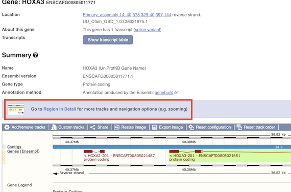

Chose some tracks to show, exported the image.

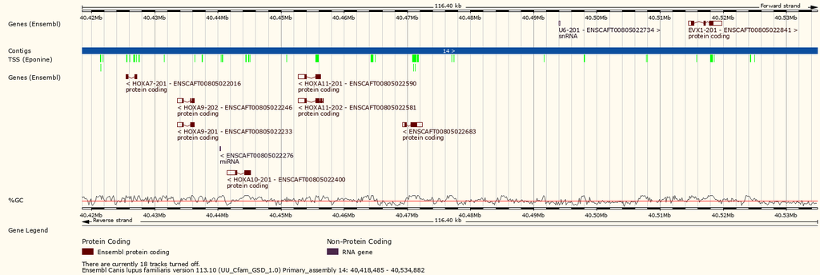

Changes:

- Zoomed out
- TSS (eponine) - Transciption start sites
- GC% Continuous, numeric data

Experiment with adding/hiding tracks:

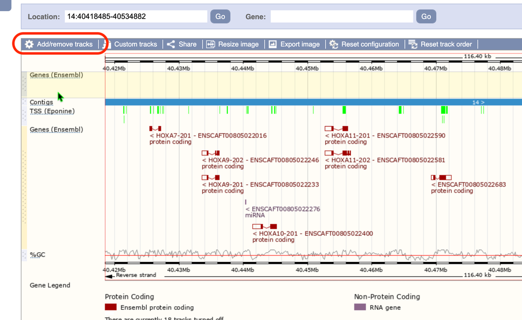

https://genome.ucsc.edu/s/davidcking/canFam4_hoxA10

They don’t have the rest of the gene cluster!?!?!

### Exercise as a group

Purpose: brainstorm how to represent data in a dataframe

**What would be a good tidy way to represent track data in a dataframe?**

- What would the rows be?
- What would the columns be?
- How many observations per row?

```r
library(rtracklayer) # for import
hoxA4_url = "https://useast.ensembl.org/Canis_lupus_familiarisgermanshepherd/Export/Output/Gene?db=core;flank3_display=0;flank5_display=0;g=ENSCAFG00805011771;output=gff3;r=14:40378329-40397144;strand=feature;t=ENSCAFT00805021651;param=gene;param=transcript;param=exon;param=intron;param=cds;_format=Text"
# you can see the requested fields listed above

# download it for import
download.file(hoxA4_url,
              "hoxA4.gff",
              headers = c("User-Agent" = "curl/7.88.1")) # had to figure this out, not always necessary
hoxA4 = import("hoxA4.gff")
```

### GFF format definition

https://useast.ensembl.org/info/website/upload/gff.html

Fields Fields must be tab-separated. Also, all but the final field in each feature line must contain a value; “empty” columns should be denoted with a ‘.’

1. seqname - name of the chromosome or scaffold; chromosome names can be given with or without the ‘chr’ prefix. Important note: the seqname must be one used within Ensembl, i.e. a standard chromosome name or an Ensembl identifier such as a scaffold ID, without any additional content such as species or assembly. See the example GFF output below.
2. source - name of the program that generated this feature, or the data source (database or project name)
3. feature - feature type name, e.g. Gene, Variation, Similarity
4. start - Start position* of the feature, with sequence numbering starting at 1.
5. end - End position* of the feature, with sequence numbering starting at 1.
6. score - A floating point value.
7. strand - defined as + (forward) or - (reverse).
8. frame - One of ‘0’, ‘1’ or ‘2’. ‘0’ indicates that the first base of the feature is the first base of a codon, ‘1’ that the second base is the first base of a codon, and so on..
9. attribute - A semicolon-separated list of tag-value pairs, providing additional information about each feature.

#### Our example from dog

| seq | src | feat | start | stop | 6 | 7 | 8 | Attributes |
| --- | --- | --- | --- | --- | --- | --- | --- | --- |
| 14 | Ensembl | gene | 40378329 | 40397144 | . | - | . | ID=**ENSCAFG00805011771.1**;Name=ENSCAFG00805011771.1;biotype=protein_coding |
| 14 | Ensembl | trans | 40378329 | 40397144 | . | - | . | ID=ENSCAFT00805021651.1;Name=ENSCAFT00805021651.1;Parent=**ENSCAFG00805011771.1**;biotype=protein_coding |
| 14 | Ensembl | exon | 40396965 | 40397144 | . | - | . | Name=ENSCAFE00805100774;Parent=ENSCAFT00805021651.1 |

Some annoyances:

#### BED - (Browser Extensible Data)

UCSC Genome Browser

https://genome.ucsc.edu/FAQ/FAQformat.html#format1

```r
bed_hoxA4 = gff_gene_to_bed(hoxA4, 'hoxA4')
bed_hoxA4
```

```
##   chrom    start      end  name score strand thickStart thickEnd itemRgb
## 1 chr14 40378328 40397144 hoxA4  1000      -   40378328 40381051       0
##   blockCount     blockSizes        blockStarts
## 1          4 800,649,83,180 0,2194,14267,18636
```

```r
write.table(bed_hoxA4, "hoxA4.bed",row.names = FALSE, quote = FALSE, sep = "\t", col.names=F)
```

### Advanced

Go to the [UCSC Genome browser](https://genome.ucsc.edu/s/davidcking/canFam4_hoxA10) and upload the `hoxA4.bed` that was created in the previous chunk by going to  
* My Data –> Custom Tracks https://genome.ucsc.edu/cgi-bin/hgCustom